# S&P 500: Great Depression vs. 2008 Financial Crisis

William Chiu

5/17/2020

# Summary

The stock market recovery from the Great Depression (of 1929) was very slow compared to the recovery from the Financial Crisis (of 2008). The document compares the daily performance of `$10,000` invested one month prior to the beginning of each recession.

A portfolio of `$10,000` at the beginning of the Great Depression never recovers even after 12.5 years. In stark contrast, a portfolio of `$10,000` recovers approximately 5.3 years after the Financial Crisis.

The document excludes the effect of dividends.

I thank the author of this [R tutorial](https://www.codingfinance.com/post/2018-03-27-download-price/). I also want to thank the author of this [other tutorial](https://blog.exploratory.io/introducing-time-series-analysis-with-dplyr-60683587cf8a). And [this tutorial](https://stackoverflow.com/questions/23518605/add-an-index-numeric-id-column-to-large-data-frame/23518737). One of the best things about using R is the ease of copying and pasting other people’s code.

Advanced users may adjust the ticker symbol and initial investment dates in the chunk below and re-run the analysis.

```r
### document parameters

ticker <- "^GSPC"

GDstartdate <- '1929-07-01'
FCstartdate <- '2007-11-01'
```

# Data

Extract historical data for the S&P 500 from Yahoo Finance.

```r
library(tidyverse)
library(tidyquant)

GSPC <- tq_get(ticker, from = '1927-01-01',
           to = "2020-05-17",
               get = "stock.prices")

head(GSPC)
```

```
## # A tibble: 6 x 8
##   symbol date        open  high   low close volume adjusted
##   <chr>  <date>     <dbl> <dbl> <dbl> <dbl>  <dbl>    <dbl>
## 1 ^GSPC  1927-12-30  17.7  17.7  17.7  17.7      0     17.7
## 2 ^GSPC  1928-01-03  17.8  17.8  17.8  17.8      0     17.8
## 3 ^GSPC  1928-01-04  17.7  17.7  17.7  17.7      0     17.7
## 4 ^GSPC  1928-01-05  17.5  17.5  17.5  17.5      0     17.5
## 5 ^GSPC  1928-01-06  17.7  17.7  17.7  17.7      0     17.7
## 6 ^GSPC  1928-01-09  17.5  17.5  17.5  17.5      0     17.5
```

# Recession Dates

According to the [NBER](https://www.nber.org/cycles.html) the Great Depression began on `August 1929` while the 2008 Financial Crisis began on `December 2007`. In order to simulate the performance of a portfolio that began immediately prior to the beginning of the recession, the document assumes `$10,000` was invested in the S&P 500 on the following dates:

- 1929-07-01
- 2007-11-01

```r
GSPC %>%
  filter(date >= GDstartdate) %>%
  head()
```

```
## # A tibble: 6 x 8
##   symbol date        open  high   low close volume adjusted
##   <chr>  <date>     <dbl> <dbl> <dbl> <dbl>  <dbl>    <dbl>
## 1 ^GSPC  1929-07-01  27.8  27.8  27.8  27.8      0     27.8
## 2 ^GSPC  1929-07-02  28.1  28.1  28.1  28.1      0     28.1
## 3 ^GSPC  1929-07-03  28.2  28.2  28.2  28.2      0     28.2
## 4 ^GSPC  1929-07-05  28.3  28.3  28.3  28.3      0     28.3
## 5 ^GSPC  1929-07-08  28.4  28.4  28.4  28.4      0     28.4
## 6 ^GSPC  1929-07-09  28.3  28.3  28.3  28.3      0     28.3
```

```r
GSPC %>%
  filter (date >= FCstartdate) %>%
  head()
```

```
## # A tibble: 6 x 8
##   symbol date        open  high   low close     volume adjusted
##   <chr>  <date>     <dbl> <dbl> <dbl> <dbl>      <dbl>    <dbl>
## 1 ^GSPC  2007-11-01 1546. 1546. 1507. 1508. 4241470000    1508.
## 2 ^GSPC  2007-11-02 1511. 1513. 1493. 1510. 4285990000    1510.
## 3 ^GSPC  2007-11-05 1506. 1511. 1490. 1502. 3819330000    1502.
## 4 ^GSPC  2007-11-06 1505. 1521. 1499. 1520. 3879160000    1520.
## 5 ^GSPC  2007-11-07 1515. 1515. 1475. 1476. 4353160000    1476.
## 6 ^GSPC  2007-11-08 1475. 1482. 1450. 1475. 5439720000    1475.
```

# Splitting the Data

Split the data sets between Great Depression and Financial Crisis. Then add new variable for portfolio age (i.e., the number of days since the initial `$10,000` investment). Use calendar days rather than trading days.

```r
GD <- GSPC %>%
  filter(date >= GDstartdate) %>%
  mutate(PortfolioAge = interval(first(date), date) / days(1))

FC <- GSPC %>%
  filter (date >= FCstartdate) %>%
  mutate(PortfolioAge = interval(first(date), date) / days(1))

head(GD)
```

```
## # A tibble: 6 x 9
##   symbol date        open  high   low close volume adjusted PortfolioAge
##   <chr>  <date>     <dbl> <dbl> <dbl> <dbl>  <dbl>    <dbl>        <dbl>
## 1 ^GSPC  1929-07-01  27.8  27.8  27.8  27.8      0     27.8            0
## 2 ^GSPC  1929-07-02  28.1  28.1  28.1  28.1      0     28.1            1
## 3 ^GSPC  1929-07-03  28.2  28.2  28.2  28.2      0     28.2            2
## 4 ^GSPC  1929-07-05  28.3  28.3  28.3  28.3      0     28.3            4
## 5 ^GSPC  1929-07-08  28.4  28.4  28.4  28.4      0     28.4            7
## 6 ^GSPC  1929-07-09  28.3  28.3  28.3  28.3      0     28.3            8
```

```r
head(FC)
```

```
## # A tibble: 6 x 9
##   symbol date        open  high   low close     volume adjusted PortfolioAge
##   <chr>  <date>     <dbl> <dbl> <dbl> <dbl>      <dbl>    <dbl>        <dbl>
## 1 ^GSPC  2007-11-01 1546. 1546. 1507. 1508. 4241470000    1508.            0
## 2 ^GSPC  2007-11-02 1511. 1513. 1493. 1510. 4285990000    1510.            1
## 3 ^GSPC  2007-11-05 1506. 1511. 1490. 1502. 3819330000    1502.            4
## 4 ^GSPC  2007-11-06 1505. 1521. 1499. 1520. 3879160000    1520.            5
## 5 ^GSPC  2007-11-07 1515. 1515. 1475. 1476. 4353160000    1476.            6
## 6 ^GSPC  2007-11-08 1475. 1482. 1450. 1475. 5439720000    1475.            7
```

# Calculate the cumulative returns

```r
GD2 <- GD %>%
  mutate(CumReturn1929 = adjusted / first(adjusted)) %>%
  select(PortfolioAge, date, adjusted, CumReturn1929)

FC2 <- FC %>%
  mutate(CumReturn2008 = adjusted / first(adjusted)) %>%
  select(PortfolioAge, date, adjusted, CumReturn2008)

head(GD2)
```

```
## # A tibble: 6 x 4
##   PortfolioAge date       adjusted CumReturn1929
##          <dbl> <date>        <dbl>         <dbl>
## 1            0 1929-07-01     27.8          1
## 2            1 1929-07-02     28.1          1.01
## 3            2 1929-07-03     28.2          1.01
## 4            4 1929-07-05     28.3          1.02
## 5            7 1929-07-08     28.4          1.02
## 6            8 1929-07-09     28.3          1.02
```

```r
head(FC2)
```

```
## # A tibble: 6 x 4
##   PortfolioAge date       adjusted CumReturn2008
##          <dbl> <date>        <dbl>         <dbl>
## 1            0 2007-11-01    1508.         1
## 2            1 2007-11-02    1510.         1.00
## 3            4 2007-11-05    1502.         0.996
## 4            5 2007-11-06    1520.         1.01
## 5            6 2007-11-07    1476.         0.978
## 6            7 2007-11-08    1475.         0.978
```

# Merge the returns by Portfolio Age

```r
GD_FC <- GD2 %>%
  inner_join(FC2, by="PortfolioAge") %>%
  select(PortfolioAge, CumReturn1929, CumReturn2008)

head(GD_FC)
```

```
## # A tibble: 6 x 3
##   PortfolioAge CumReturn1929 CumReturn2008
##          <dbl>         <dbl>         <dbl>
## 1            0          1            1
## 2            1          1.01         1.00
## 3            4          1.02         0.996
## 4            7          1.02         0.978
## 5            8          1.02         0.964
## 6           11          1.03         0.954
```

We’re almost done. We need to multiply the cumulative returns by `$10,000` to get the value of the portfolio in dollar terms.

```r
GD_FC2 <- GD_FC %>%
  mutate(GreatDepression1929 = CumReturn1929*10000,
          FinancialCrisis2008 = CumReturn2008*10000)

head(GD_FC2)
```

```
## # A tibble: 6 x 5
##   PortfolioAge CumReturn1929 CumReturn2008 GreatDepression19… FinancialCrisis20…
##          <dbl>         <dbl>         <dbl>              <dbl>              <dbl>
## 1            0          1            1                 10000              10000
## 2            1          1.01         1.00              10104.             10008.
## 3            4          1.02         0.996             10198.              9958.
## 4            7          1.02         0.978             10216.              9777.
## 5            8          1.02         0.964             10184.              9637.
## 6           11          1.03         0.954             10288.              9541.
```

# Convert columns to rows

This part is a little tricky. The columns `GreatDepression1929` and `FinancialCrisis2008` should be converted into rows with a new column (i.e., `Type`) to distinguish between the 1929 and 2008 portfolios. I perform this step to make plotting easier.

```r
GD_FC2_gather <- GD_FC2 %>%
  select(PortfolioAge, GreatDepression1929, FinancialCrisis2008) %>%
  gather("Type", "PortfolioValue", -PortfolioAge)

head(GD_FC2_gather)
```

```
## # A tibble: 6 x 3
##   PortfolioAge Type                PortfolioValue
##          <dbl> <chr>                        <dbl>
## 1            0 GreatDepression1929         10000
## 2            1 GreatDepression1929         10104.
## 3            4 GreatDepression1929         10198.
## 4            7 GreatDepression1929         10216.
## 5            8 GreatDepression1929         10184.
## 6           11 GreatDepression1929         10288.
```

```r
tail(GD_FC2_gather)
```

```
## # A tibble: 6 x 3
##   PortfolioAge Type                PortfolioValue
##          <dbl> <chr>                        <dbl>
## 1         4568 FinancialCrisis2008         18846.
## 2         4571 FinancialCrisis2008         19100.
## 3         4572 FinancialCrisis2008         19423.
## 4         4575 FinancialCrisis2008         19425.
## 5         4578 FinancialCrisis2008         18910.
## 6         4579 FinancialCrisis2008         18985.
```

# Plot

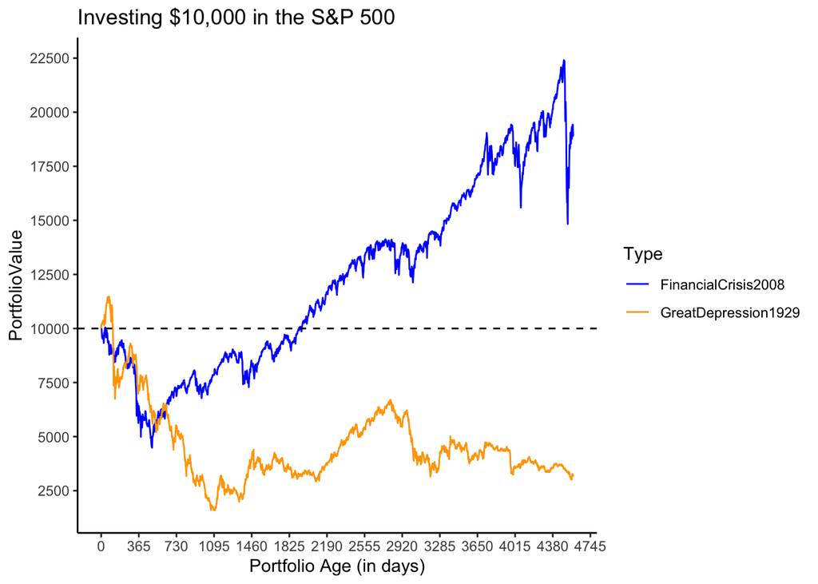

```r
ggplot(GD_FC2_gather, aes(x=PortfolioAge, y=PortfolioValue)) +
  geom_line(aes(color=Type)) +
  theme_classic() +
  geom_hline(yintercept=10000, linetype="dashed", color = "black") +
  scale_y_continuous(breaks=seq(0,25000,2500)) +
  scale_x_continuous(name="Portfolio Age (in days)",breaks=seq(0,365*13,365)) +
  scale_color_manual(values=c('blue','orange')) +
  ggtitle("Investing $10,000 in the S&P 500")
```

# Conclusion

Had you invested `$10,000` on `1929-07-01`, your portfolio would have been worth about `$3,000` after 12.5 years. In stark contrast, if you invested `$10,000` on `2007-11-01`, your portfolio would have been worth about `$19,000` after 12.5 years.